# Final Project Project Report 2

Isaac Chen

March 02, 2025

## Setup

```r
# Clear all the variables in the environment
rm(list = ls())

# Print warnings immediately as they come up for troubleshooting purposes
options(warn = 1)

# Load packages
library(here) # Used to find files relative to my project root
library(tidyverse) # Used to tidying data
library(skimr) # Used to create data summary
library(ggrain) # Used to create raincloud plots

# For reproducibility
set.seed(123)
```

## Objective

For this progress report I want you to begin describing patterns in your dependent variable.

## Load Data

Let’s first load in the R data file from the [Baby’s First Years (BFY)](https://www.childandfamilydataarchive.org/cfda/archives/cfda/studies/37871/summary) project. Specifically, I will be loading in data collected at age 1 years old.

```r
# Load data
data <- here("data", "ICPSR_37871", "DS0002", "37871-0002-Data.rda")
load(data)
```

Next, let’s created a more simplified dataset with a few variables of interest. Then we will drop any rows that contain missing values.

```r
# Variable selection
byf_a1 <- da37871.0002 |>
  select(
    TREAT, CHILDGENDERA1, RHOMELESSA1, DAYCAREA1, CDISABILITYA1, CPRIMLANGTA1,
    READBOOKSA1, PLAYGROUPA1, TOTEARNEDINCOMEA1, CASQLANGA1, CASQLANGCUTOFFA1
  ) |>
  drop_na()
```

After removing all the missing data, we are left with 896 participants.

Here is a code book of the variables selected:

**Predictors**:

- `TREAT` - Treatment group status
  - 1 = high cash gift group
  - 0 = low cash gift group
- `CHILDGENDERA1` - Child Gender
  - 1 = Boy
  - 5 = Girl
- `RHOMELESSA1` - Since [CHILD]’s birth, have you ever been homeless?
  - 1 = Yes
  - 5 = No
- `DAYCAREA1` - Has [CHILD] spent any time in a child care or day care center?
  - 1 = Yes
  - 5 = No
- `CDISABILITYA1` - Has [CHILD] been diagnosed with any health condition or disability since birth?
  - 1 = Yes
  - 5 = No
- `CPRIMLANGTA1` - How often does your child hear [PRIMARY LANGUAGE]? Would you say: almost always [PRIMARY LANGUAGE], mostly [PRIMARY LANGUAGE], or about half [PRIMARY LANGUAGE] and half other. language(s)?;
  - 1 = Almost always [PRIMARY LANGUAGE]
  - 2 = Mostly [PRIMARY LANGUAGE]
  - 3 = Half [PRIMARY LANGUAGE] and half other.
- `READBOOKSA1` - How often do you read books or look at pictures in a book with [CHILD]? Would you say: Every day, A few times a week, A few times a month or Rarely or not at all?
  - 1 = Everyday
  - 2 = A few times a week
  - 3 = A few times a month
  - 4 = Rarely or not at all.
- `PLAYGROUPA1` - How often do you go to any out-of-the home activities or programs that are specifically for babies, like Mommy and Me, library story times, and play groups?
  - 1 = Every day
  - 2 = A few times a week
  - 3 = A few times a month
  - 4 = Rarely or not at all.
- `TOTEARNEDINCOMEA1` - How much did you earn from all your employers before taxes and deductions during the previous year? (continuous variable)

**Outcome**:

- `CASQLANGA1` - ASQ Communication Language Scale (standardized scores)
- `CASQLANGCUTOFFA` - ASQ Communication cutoff
  - 1 = Score below cutoff (2 SD below mean)
  - 2 = Score close to cutoff (between 1 and 2 SD below mean)
  - 3 = Score close to cutoff (between 1 and 2 SD below mean).

Get some useful summary statistics

```r
# Data summary
skim(byf_a1)
```

Data summary

| Name | byf_a1 |
| --- | --- |
| Number of rows | 896 |
| Number of columns | 11 |
| _______________________ |  |
| Column type frequency: |  |
| factor | 9 |
| numeric | 2 |
| ________________________ |  |
| Group variables | None |

**Variable type: factor**

| skim_variable | n_missing | complete_rate | ordered | n_unique | top_counts |
| --- | --- | --- | --- | --- | --- |
| TREAT | 0 | 1 | FALSE | 2 | (0): 520, (1): 376 |
| CHILDGENDERA1 | 0 | 1 | FALSE | 2 | (1): 453, (5): 443 |
| RHOMELESSA1 | 0 | 1 | FALSE | 2 | (5): 842, (1): 54 |
| DAYCAREA1 | 0 | 1 | FALSE | 2 | (5): 646, (1): 250 |
| CDISABILITYA1 | 0 | 1 | FALSE | 2 | (5): 773, (1): 123 |
| CPRIMLANGTA1 | 0 | 1 | FALSE | 3 | (1): 674, (3): 120, (2): 102 |
| READBOOKSA1 | 0 | 1 | FALSE | 4 | (2): 454, (1): 246, (4): 107, (3): 89 |
| PLAYGROUPA1 | 0 | 1 | FALSE | 4 | (4): 632, (2): 126, (3): 111, (1): 27 |
| CASQLANGCUTOFFA1 | 0 | 1 | FALSE | 3 | (3): 810, (2): 72, (1): 14 |

**Variable type: numeric**

| skim_variable | n_missing | complete_rate | mean | sd | p0 | p25 | p50 | p75 | p100 | hist |
| --- | --- | --- | --- | --- | --- | --- | --- | --- | --- | --- |
| TOTEARNEDINCOMEA1 | 0 | 1 | 7344.50 | 10017.71 | 0.00 | 0.00 | 4000.00 | 1.2e+04 | 1.50e+05 | ▇▁▁▁▁ |
| CASQLANGA1 | 0 | 1 | 0.24 | 0.87 | -3.23 | -0.23 | 0.49 | 9.9e-01 | 1.22e+00 | ▁▁▂▃▇ |

For this progress report, I will focus my analyses on the continuous variable `CASQLANGA1`, but I think it may be useful to use categorical outcomes given that the methods we have learned in this course have been focused on classification.

## Univariate analysis

1. Univariate analysis: provide appropriate measures of central tendency and variability for your dependent variable. If your dv is continuous, provide graphics showing the distribution of your variable.

Raincloud plot of `CASQLANGA1`

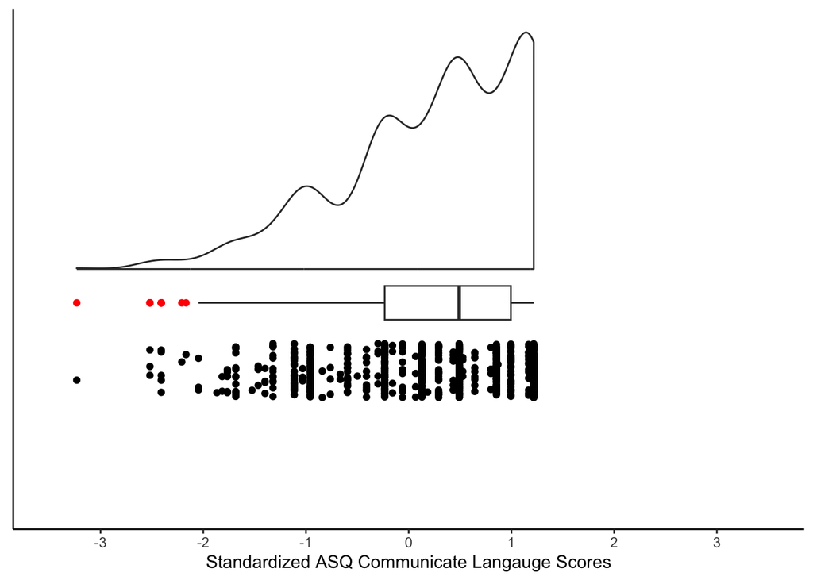

```r
# Raincloud plot
byf_a1 |>
  ggplot(aes(1, CASQLANGA1)) +
  geom_rain(boxplot.args = list(outlier.color = "red")) +
  labs(y = "Standardized ASQ Communicate Langauge Scores") +
  scale_y_continuous(limits = c(-3.5, 3.5), breaks = seq(-3, 3, 1)) +
  theme_classic() +
  theme(
    axis.title.y = element_blank(),
    axis.text.y = element_blank(),
    axis.ticks.y = element_blank()
  ) +
  coord_flip()
```

## Bivariate analysis

2. Bivariate analysis: provide the conditional mean of your dependent variable as function of at least three and no more than five of your independent variables. Provide the results in a table or graphic. Remember to use the group_by –> summarize approach, where group_by is based on a categorical or discretized independent variable.

Relationship between `CASQLANGA1` and `TREAT`

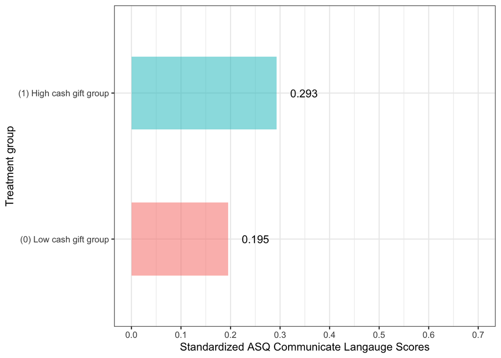

```r
# Bar chart
byf_a1 |>
  group_by(TREAT) |>
  summarize(mean = round(mean(CASQLANGA1, na.rm = TRUE), 3)) |>
  ggplot(aes(x = TREAT, y = mean, fill = TREAT)) +
  geom_col(alpha = 0.5, width = 0.5) +
  geom_text(aes(label = paste0(mean), hjust = -0.5)) +
  scale_y_continuous(limits = c(0, 0.7), breaks = seq(0, 0.7, 0.1)) +
  labs(
    x = "Treatment group",
    y = "Standardized ASQ Communicate Langauge Scores"
  ) +
  coord_flip() +
  theme_bw() +
  theme(legend.position = "none")
```

Relationship between `CASQLANGA1` and `DAYCAREA1`

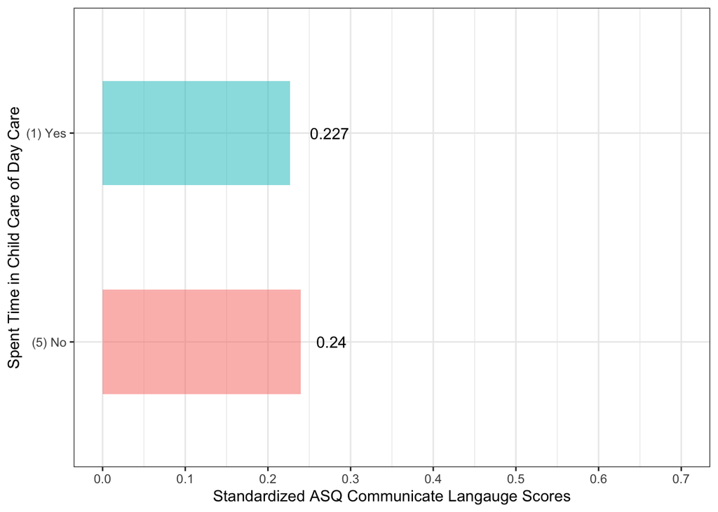

```r
# Bar chart
byf_a1 |>
  group_by(DAYCAREA1) |>
  summarize(mean = round(mean(CASQLANGA1, na.rm = TRUE), 3)) |>
  ggplot(aes(x = fct_rev(DAYCAREA1), y = mean, fill = fct_rev(DAYCAREA1))) +
  geom_col(alpha = 0.5, width = 0.5) +
  geom_text(aes(label = paste0(mean), hjust = -0.5)) +
  scale_y_continuous(limits = c(0, 0.7), breaks = seq(0, 0.7, 0.1)) +
  labs(
    x = "Spent Time in Child Care of Day Care",
    y = "Standardized ASQ Communicate Langauge Scores"
  ) +
  coord_flip() +
  theme_bw() +
  theme(legend.position = "none")
```

Relationship between `CASQLANGA1` and `READBOOKSA1`

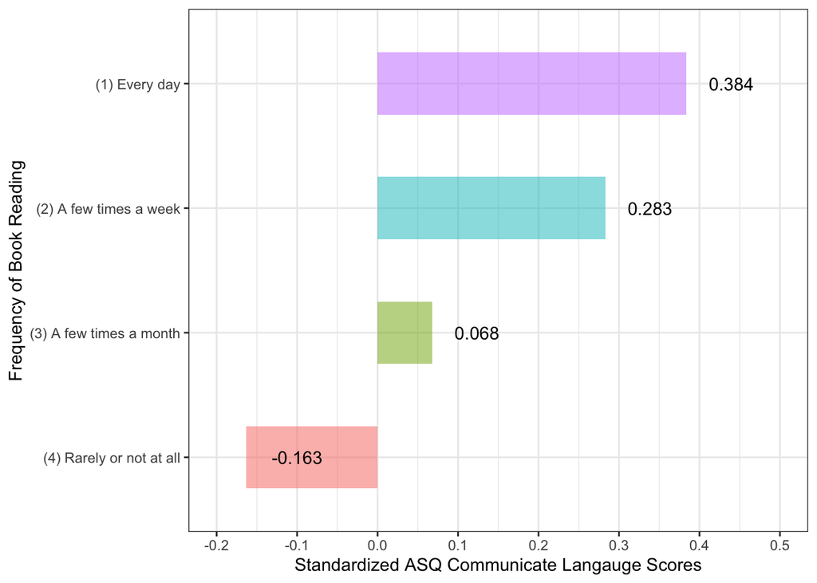

```r
# Bar chart
byf_a1 |>
  group_by(READBOOKSA1) |>
  summarize(mean = round(mean(CASQLANGA1, na.rm = TRUE), 3)) |>
  ggplot(aes(x = fct_rev(READBOOKSA1), y = mean, fill = fct_rev(READBOOKSA1))) +
  geom_col(alpha = 0.5, width = 0.5) +
  geom_text(aes(label = paste0(mean), hjust = -0.5)) +
  scale_y_continuous(limits = c(-0.2, 0.5), breaks = seq(-0.2, 0.7, 0.1)) +
  labs(
    x = "Frequency of Book Reading",
    y = "Standardized ASQ Communicate Langauge Scores"
  ) +
  coord_flip() +
  theme_bw() +
  theme(legend.position = "none")
```

Relationship between `CASQLANGA1` and `PLAYGROUPA1`

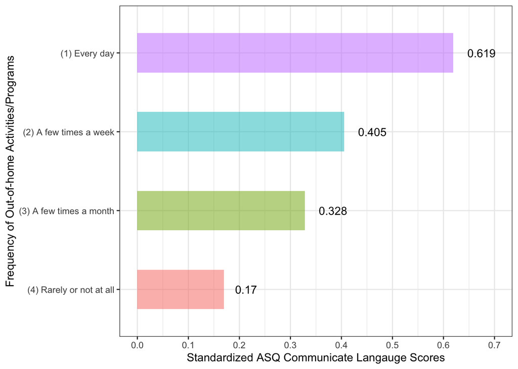

```r
# Bar chart
byf_a1 |>
  group_by(PLAYGROUPA1) |>
  summarize(mean = round(mean(CASQLANGA1, na.rm = TRUE), 3)) |>
  ggplot(aes(x = fct_rev(PLAYGROUPA1), y = mean, fill = fct_rev(PLAYGROUPA1))) +
  geom_col(alpha = 0.5, width = 0.5) +
  geom_text(aes(label = paste0(mean), hjust = -0.5)) +
  scale_y_continuous(limits = c(0, 0.7), breaks = seq(0, 0.7, 0.1)) +
  labs(
    x = "Frequency of Out-of-home Activities/Programs",
    y = "Standardized ASQ Communicate Langauge Scores"
  ) +
  coord_flip() +
  theme_bw() +
  theme(legend.position = "none")
```

Relationship between `CASQLANGA1` and `TOTEARNEDINCOMEA1`

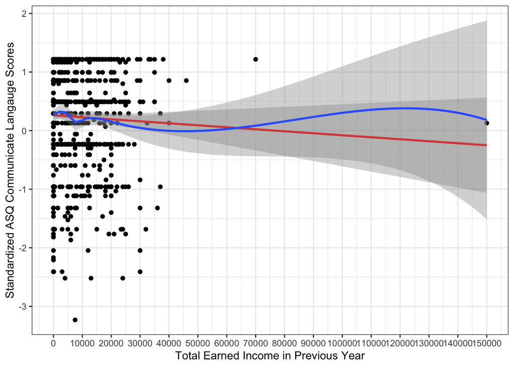

```r
# Scatter plot
byf_a1 |>
  ggplot(aes(x = TOTEARNEDINCOMEA1, y = CASQLANGA1)) +
  geom_point() +
  geom_smooth(method = lm, col = "red") +
  geom_smooth(method = "loess") +
  scale_x_continuous(limits = c(0, 150000), breaks = seq(0, 150000, 10000)) +
  labs(
    x = "Total Earned Income in Previous Year",
    y = "Standardized ASQ Communicate Langauge Scores"
  ) +
  theme_bw()
```